# Final Project Analysis

3. Independence of errors: This data consists of several different measurements of 252 people. Biologically, there many be some dependence across variables. However, the data does not contain repeated measurements from them same individual over time, instead each variable was measured a single time for each person. Overall, it is important to be aware in our analysis that there many be some level of biological association between the variables included in our analysis but the independence of errors assumption generally holds since there are no repeated measurements and there is no clustering within the data.
4. Normality of Residuals

```r
shapiro.test(resid(mod))
```

```
##
##  Shapiro-Wilk normality test
##
## data:  resid(mod)
## W = 0.38038, p-value < 2.2e-16
```

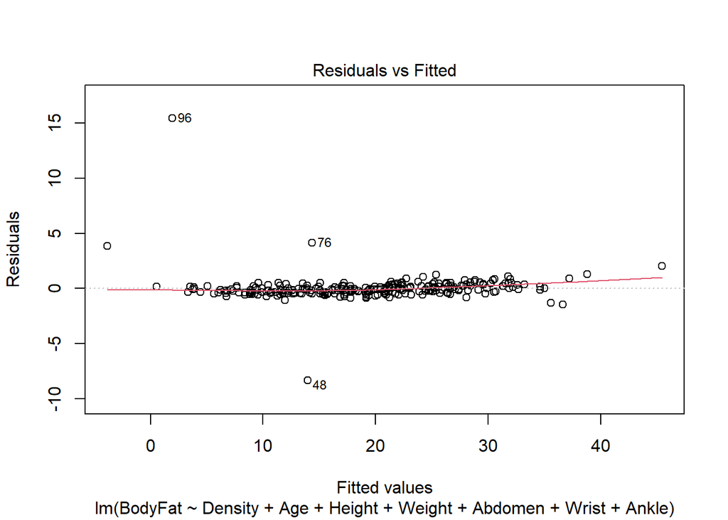

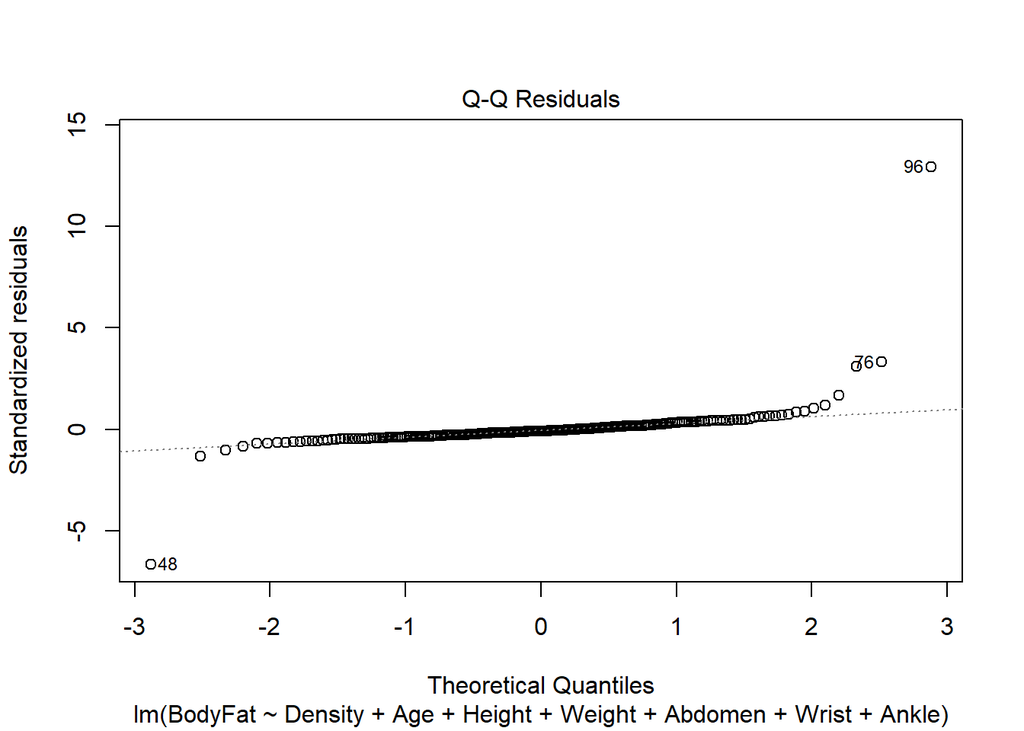

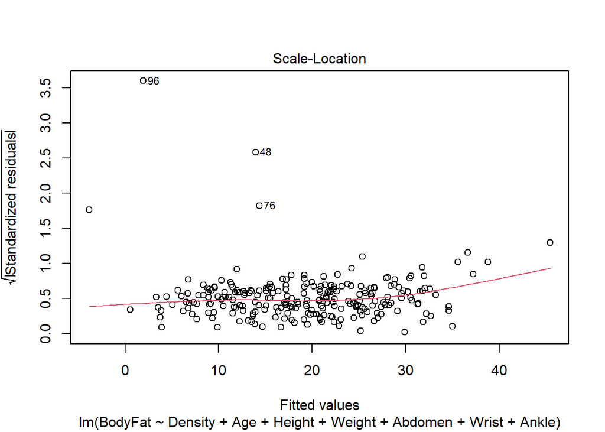

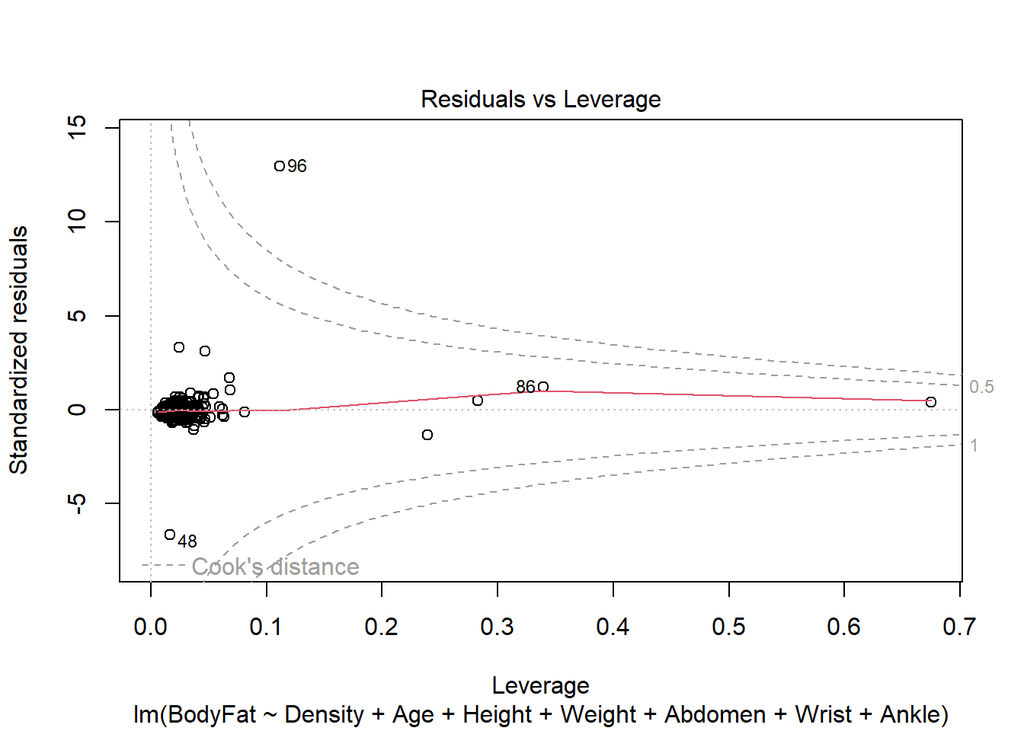

```r
plot(mod)
```

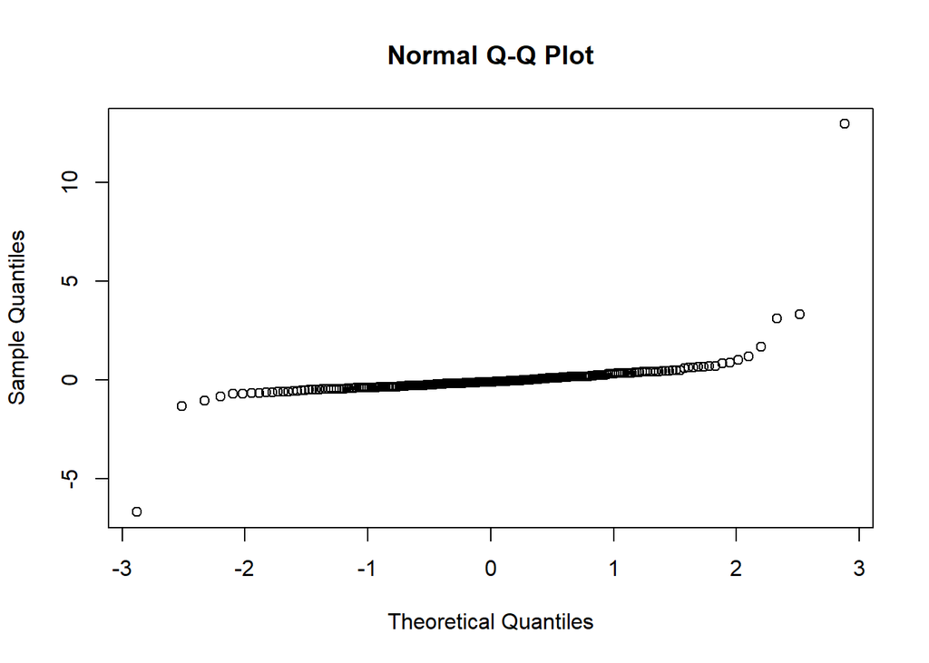

```r
qqnorm(rstandard(mod))
```

These tests and visualizations indicate that the residuals are not normally distributed. The heavy tailed qqplot suggests that there is more data at the extreme values. There are 252 data points in our data set, so it the impact of this is not as large as it would be for a smaller data set. While important to consider, the normality of errors assumption is more important for inference than point estimates and so we will continue on to evaluate the remaining assumptions.

5. Multicollinearity

```r
vif(mod)
```

```
##   Density       Age    Height    Weight   Abdomen     Wrist     Ankle
##  3.524224  1.731635  1.377029 12.799782 13.738476  2.962577  1.818001
```

### Assumption Violation Handling

- Multicollinearity: Remove Abdomen from the model due to its high VIF and assess multicollinearity for our new model.

```r
lm(BodyFat ~ Density + Age +Height + Weight + Wrist + Ankle,
   data = body_data) -> mod2
summary(mod2)
```

```
##
## Call:
## lm(formula = BodyFat ~ Density + Age + Height + Weight + Wrist +
##     Ankle, data = body_data)
##
## Residuals:
##     Min      1Q  Median      3Q     Max
## -8.4253 -0.3673 -0.1039  0.2079 15.5233
##
## Coefficients:
##               Estimate Std. Error t value Pr(>|t|)
## (Intercept)  4.578e+02  6.468e+00  70.772  < 2e-16 ***
## Density     -4.159e+02  6.206e+00 -67.018  < 2e-16 ***
## Age          1.806e-02  7.669e-03   2.355 0.019288 *
## Height      -1.557e-02  2.485e-02  -0.626 0.531591
## Weight       1.913e-02  5.687e-03   3.363 0.000894 ***
## Wrist       -2.855e-02  1.470e-01  -0.194 0.846205
## Ankle       -9.542e-02  6.260e-02  -1.524 0.128740
## ---
## Signif. codes:  0 '***' 0.001 '**' 0.01 '*' 0.05 '.' 0.1 ' ' 1
##
## Residual standard error: 1.265 on 245 degrees of freedom
## Multiple R-squared:  0.9777, Adjusted R-squared:  0.9771
## F-statistic:  1790 on 6 and 245 DF,  p-value: < 2.2e-16
```

```r
vif(mod2)
```

```
##  Density      Age   Height   Weight    Wrist    Ankle
## 2.187324 1.464572 1.299639 4.380841 2.954938 1.765288
```

Now, we can see that while Weight has a higher VIF, the other variables do not. We can continue to include Weight in the model but as a control variable due to the multicollinearity present. Moving forward, we will now use the model that does not include Abdomen.

- Hetroskedascitity: Heteroskedasticity can lead to incorrect p-values and confidence intervals. To address this violation of the homoskedasticity assumption, we will use robust standard errors for our analysis below.

### Variable Selection and Hypothesis Testing

#### Model Selection

When creating our model, we must consider the bias-variance trade-off. Including more predictors may decrease our bias but it will increase our variance. To determine which variables to keep in our model, we will perform stepwise selection with forward and backwards selection with BIC.

```r
#start with smallest model
intOnly <- lm(BodyFat~ 1, data = body_data)

#biggest model
mod_big <- lm(BodyFat ~ ., data = body_data)

#use step function for forward selection: will read AIC but use K argument for BIC output

out_forward_bic <- step(object = intOnly, direction = "forward",
                        scope = formula(mod_big), trace = T, k = log(nrow(body_data)))
```

```
## Start:  AIC=1075.28
## BodyFat ~ 1
##
##           Df Sum of Sq     RSS     AIC
## + Density  1   17152.1   426.9  143.91
## + Abdomen  1   11631.5  5947.5  807.70
## + Chest    1    8678.3  8900.7  909.30
## + Hip      1    6871.2 10707.8  955.88
## + Weight   1    6593.0 10986.0  962.35
## + Thigh    1    5505.0 12073.9  986.14
## + Knee     1    4548.4 13030.6 1005.36
## + Biceps   1    4277.3 13301.7 1010.55
## + Neck     1    4230.9 13348.1 1011.42
## + Forearm  1    2295.8 15283.2 1045.54
## + Wrist    1    2111.5 15467.5 1048.56
## + Age      1    1493.3 16085.7 1058.44
## + Ankle    1    1243.5 16335.5 1062.32
## <none>                 17579.0 1075.28
## + Height   1     140.8 17438.2 1078.78
##
## Step:  AIC=143.91
## BodyFat ~ Density
##
##           Df Sum of Sq    RSS    AIC
## + Abdomen  1   28.5567 398.37 131.99
## + Chest    1   26.4765 400.45 133.30
## + Weight   1   17.8177 409.10 138.69
## + Hip      1   15.1976 411.72 140.30
## + Neck     1   12.4035 414.52 142.01
## + Wrist    1   12.1324 414.79 142.17
## <none>                 426.92 143.91
## + Knee     1    9.0122 417.91 144.06
## + Age      1    5.6436 421.28 146.08
## + Thigh    1    4.4625 422.46 146.79
## + Forearm  1    3.9512 422.97 147.09
## + Biceps   1    3.3820 423.54 147.43
## + Height   1    0.9175 426.00 148.89
## + Ankle    1    0.3522 426.57 149.23
##
## Step:  AIC=131.99
## BodyFat ~ Density + Abdomen
##
##           Df Sum of Sq    RSS    AIC
## <none>                 398.37 131.99
## + Age      1    5.2736 393.09 134.16
## + Ankle    1    3.2258 395.14 135.47
## + Thigh    1    3.1472 395.22 135.52
## + Biceps   1    2.0070 396.36 136.25
## + Chest    1    1.4196 396.95 136.62
## + Hip      1    0.5715 397.79 137.16
## + Weight   1    0.4411 397.92 137.24
## + Knee     1    0.4231 397.94 137.25
## + Height   1    0.2979 398.07 137.33
## + Neck     1    0.1494 398.22 137.42
## + Forearm  1    0.0179 398.35 137.51
## + Wrist    1    0.0179 398.35 137.51
```

```r
#use step function for backward selection: will read AIC but use K argument for BIC output
out_backward_bic <- step(object = mod_big, direction = "backward",
                         scope = formula(mod_big), trace = T, k = log(nrow(body_data)))
```

```
## Start:  AIC=189.65
## BodyFat ~ Density + Age + Weight + Height + Neck + Chest + Abdomen +
##     Hip + Thigh + Knee + Ankle + Biceps + Forearm + Wrist
##
##           Df Sum of Sq    RSS    AIC
## - Wrist    1       0.0  384.9 184.12
## - Knee     1       0.0  384.9 184.12
## - Height   1       0.1  385.0 184.20
## - Thigh    1       0.2  385.1 184.28
## - Neck     1       0.3  385.1 184.30
## - Hip      1       0.3  385.2 184.33
## - Forearm  1       0.5  385.4 184.46
## - Abdomen  1       0.6  385.4 184.48
## - Weight   1       0.6  385.5 184.54
## - Chest    1       1.4  386.2 185.00
## - Biceps   1       1.9  386.8 185.36
## - Ankle    1       2.8  387.6 185.92
## - Age      1       2.8  387.6 185.93
## <none>                  384.9 189.65
## - Density  1    4026.6 4411.4 798.77
##
## Step:  AIC=184.12
## BodyFat ~ Density + Age + Weight + Height + Neck + Chest + Abdomen +
##     Hip + Thigh + Knee + Ankle + Biceps + Forearm
##
##           Df Sum of Sq    RSS    AIC
## - Knee     1       0.0  384.9 178.60
## - Height   1       0.1  385.0 178.67
## - Thigh    1       0.2  385.1 178.75
## - Neck     1       0.3  385.1 178.77
## - Hip      1       0.3  385.2 178.80
## - Abdomen  1       0.6  385.4 178.95
## - Forearm  1       0.6  385.4 178.96
## - Weight   1       0.7  385.5 179.03
## - Chest    1       1.3  386.2 179.47
## - Biceps   1       1.9  386.8 179.83
## - Ankle    1       2.9  387.7 180.48
## - Age      1       3.2  388.1 180.71
## <none>                  384.9 184.12
## - Density  1    4196.7 4581.6 802.78
```

[output cut: 134 more lines]

```
## BodyFat ~ Density + Age + Chest
##
##           Df Sum of Sq    RSS    AIC
## - Age      1       6.1  400.4 133.30
## <none>                  394.3 134.96
## - Chest    1      26.9  421.3 146.08
## - Density  1    7997.4 8391.7 899.99
##
## Step:  AIC=133.3
## BodyFat ~ Density + Chest
##
##           Df Sum of Sq    RSS    AIC
## <none>                  400.4 133.30
## - Chest    1      26.5  426.9 143.91
## - Density  1    8500.2 8900.7 909.30
```

The forward selection method would lead us to choose a model that includes Abdomen, which our above multicollinearity analysis have shown should be excluded.Since we are able to build the full model with all our initial variables of interest and we know from the literature that many of these variables are involved in body fat measurements, we will prefer to use backwards selection with BIC.

Following model selection we will use the model chosen from the backwards selection method:

```r
lm(BodyFat ~ Density + Chest, data = body_data) -> mod_back
summary(mod_back)
```

```
##
## Call:
## lm(formula = BodyFat ~ Density + Chest, data = body_data)
##
## Residuals:
##     Min      1Q  Median      3Q     Max
## -8.3979 -0.3402 -0.0692  0.1685 15.8090
##
## Coefficients:
##               Estimate Std. Error t value Pr(>|t|)
## (Intercept)  455.50877    7.03522  64.747  < 2e-16 ***
## Density     -418.41989    5.75531 -72.701  < 2e-16 ***
## Chest          0.05272    0.01299   4.057 6.64e-05 ***
## ---
## Signif. codes:  0 '***' 0.001 '**' 0.01 '*' 0.05 '.' 0.1 ' ' 1
##
## Residual standard error: 1.268 on 249 degrees of freedom
## Multiple R-squared:  0.9772, Adjusted R-squared:  0.977
## F-statistic:  5341 on 2 and 249 DF,  p-value: < 2.2e-16
```

#### Evaluate significance of each variable in the model:

The acceptable level of significance for our analysis is: alpha = 0.05

We will use the $H_0$: there is no association ($b = 0$) and the alternative hypothesis $H_a$: there is an association ($b \neq 0$).

```r
summary(mod_back)
```

```
##
## Call:
## lm(formula = BodyFat ~ Density + Chest, data = body_data)
##
## Residuals:
##     Min      1Q  Median      3Q     Max
## -8.3979 -0.3402 -0.0692  0.1685 15.8090
##
## Coefficients:
##               Estimate Std. Error t value Pr(>|t|)
## (Intercept)  455.50877    7.03522  64.747  < 2e-16 ***
## Density     -418.41989    5.75531 -72.701  < 2e-16 ***
## Chest          0.05272    0.01299   4.057 6.64e-05 ***
## ---
## Signif. codes:  0 '***' 0.001 '**' 0.01 '*' 0.05 '.' 0.1 ' ' 1
##
## Residual standard error: 1.268 on 249 degrees of freedom
## Multiple R-squared:  0.9772, Adjusted R-squared:  0.977
## F-statistic:  5341 on 2 and 249 DF,  p-value: < 2.2e-16
```

```r
p_adj <- p.adjust(c(2e-16, 6.64e-05), method = "bonferroni")
p_adj
```

```
## [1] 4.000e-16 1.328e-04
```

We can use the summary() function to find the t statistic for each variable in our model. We can then use the Bonferroni procedure to account for multiple testing. This is an overly conservative procedure, so it may come with a loss of power. We find that both our unadjusted and adjusted p-values are below our significance level of 0.05, so we can reject the null hypothesis of no association and conclude that there is an association present for the variables we included in our model.

#### Model Performance Techniques

```r
summary(mod_back)$r.squared
```

```
## [1] 0.9772202
```

```r
summary(mod_back)$adj.r.squared
```

```
## [1] 0.9770372
```

The $R^2$ value measures how well our model fits the training data. However, it is known that the $R^2$ value increaes with more predictors, which may lead to an overly complex model. This is why we can also evaluate the Adjusted $R^2$ measure. This penalizes for model complexity. Though the adjusted $R^2$ penalty may be weak, it will work for our model since it is not too complex and contains 2 predictors. From the summary() output for our model chosen with backwards selection with BIC, we can see that the $R^2$ and Adjusted $R^2$ value are both very similiar. They are both very high, which may be a sign that our model overfits the training data.

#### Cross Validation Techniques

We will perform cross validation using data splitting: We will split the data where 70% is for training and 30% is for testing.

```r
set.seed(1)

body_data %>%
  mutate(id = row_number(), .before = Density) -> cross_val_data

n <- dim(cross_val_data)[1]

m <- floor(n*0.7)

train_idx <- sample(1:n, m, replace = FALSE)

train_set <- cross_val_data[train_idx,]

test_set <- cross_val_data[-train_idx,]

y_true <- test_set$Density

#model with training data:
mod_a <- lm(BodyFat ~ Density + Chest, data = test_set)
summary(mod_a)
```

```
##
## Call:
## lm(formula = BodyFat ~ Density + Chest, data = test_set)
##
## Residuals:
##     Min      1Q  Median      3Q     Max
## -1.8823 -0.9620 -0.2472  0.3135 13.4995
##
## Coefficients:
##               Estimate Std. Error t value Pr(>|t|)
## (Intercept)  418.19704   17.02588  24.562  < 2e-16 ***
## Density     -389.76172   13.86039 -28.121  < 2e-16 ***
## Chest          0.12448    0.03308   3.763 0.000336 ***
## ---
## Signif. codes:  0 '***' 0.001 '**' 0.01 '*' 0.05 '.' 0.1 ' ' 1
##
## Residual standard error: 1.897 on 73 degrees of freedom
## Multiple R-squared:  0.9578, Adjusted R-squared:  0.9567
## F-statistic: 828.8 on 2 and 73 DF,  p-value: < 2.2e-16
```

```r
#Test set
y_hat_1 <- predict(mod_a, test_set)

#Calculate Mean Squared Error

pred_error_1 <- mean((y_hat_1 - y_true)^2)
pred_error_1
```

```
## [1] 400.9916
```

```r
mod_b <- lm(BodyFat ~ Density + Chest + Age, data = train_set)
summary(mod_b)
```

```
##
## Call:
## lm(formula = BodyFat ~ Density + Chest + Age, data = train_set)
##
## Residuals:
##     Min      1Q  Median      3Q     Max
## -8.5394 -0.0965  0.0002  0.1056  4.4746
##
## Coefficients:
##               Estimate Std. Error t value Pr(>|t|)
## (Intercept)  4.786e+02  5.574e+00  85.856   <2e-16 ***
## Density     -4.365e+02  4.560e+00 -95.724   <2e-16 ***
## Chest        1.050e-02  9.704e-03   1.082    0.281
## Age          3.745e-03  4.802e-03   0.780    0.436
## ---
## Signif. codes:  0 '***' 0.001 '**' 0.01 '*' 0.05 '.' 0.1 ' ' 1
##
## Residual standard error: 0.7621 on 172 degrees of freedom
## Multiple R-squared:  0.9912, Adjusted R-squared:  0.991
## F-statistic:  6455 on 3 and 172 DF,  p-value: < 2.2e-16
```

```r
y_hat_2 <- predict(mod_b, test_set)
pred_error_2 <- mean((y_hat_2 - y_true)^2)
pred_error_2
```

```
## [1] 393.9651
```

From our cross validation, it looks like we may be able to slightly decrease our MSE when adding other variables like Age. However, the above linearity assumptions and model selection would lead us to favor the simplier model selected above, especially since the MSE difference is not very large.

#### Feature Impact Analysis

For the significant coefficients, we will generate confidence intervals using the sandwhich estimator to account for the robust error method due to the heteroskedasticity.

```r
coefci(mod_back, vcov. = sandwich::vcovHC(mod_back), type = "HC3")
```

```
##                     2.5 %      97.5 %
## (Intercept)  399.01044428  512.007101
## Density     -463.24058740 -373.599192
## Chest         -0.04120099    0.146634
```

Practically, the selection of Density and Chest for inclusion in our model could represent variables that would be useful for measurement of Body Fat in the future, as compared to the many variables observed in the data set.

# Results

```r
lm(BodyFat ~ Density + Chest, data = body_data) -> mod_back
summary(mod_back)
```

```
##
## Call:
## lm(formula = BodyFat ~ Density + Chest, data = body_data)
##
## Residuals:
##     Min      1Q  Median      3Q     Max
## -8.3979 -0.3402 -0.0692  0.1685 15.8090
##
## Coefficients:
##               Estimate Std. Error t value Pr(>|t|)
## (Intercept)  455.50877    7.03522  64.747  < 2e-16 ***
## Density     -418.41989    5.75531 -72.701  < 2e-16 ***
## Chest          0.05272    0.01299   4.057 6.64e-05 ***
## ---
## Signif. codes:  0 '***' 0.001 '**' 0.01 '*' 0.05 '.' 0.1 ' ' 1
##
## Residual standard error: 1.268 on 249 degrees of freedom
## Multiple R-squared:  0.9772, Adjusted R-squared:  0.977
## F-statistic:  5341 on 2 and 249 DF,  p-value: < 2.2e-16
```

Using our model, we can say that:

Given two observations whose Density measurements differ by 1 unit when all other measures are constant, we would expect the observation with the larger Density value to have a Body Fat that is -418.41989 units smaller than the observation with the smaller Density.

Given two observations whose Chest measurements differ by 1 unit when all other measurements are constant, we would expect the observation with the larger Chest value to have a Body Fat that is 0.05272 units larger than the observation with the smaller Chest measurement.

# Discussion

# Conclusion

# References:

1. Slides, Labs, and Assignments for BTRY 6020
2. https://library.virginia.edu/data/articles/understanding-q-q-plots#:~:text=A%20QQ%20plot%20is%20a,a%20line%20that’s%20roughly%20straight.